# MLB

Set up libraries and working directory

```r
library(readr)
library(ggplot2)
library(dplyr)
setwd("C:/Users/jpano/Documents/DACourse/CSDA1010/sprints/sprint_1")
```

Load files

```r
appearances=read_csv("Appearances.csv", col_name=TRUE,na=c("","NA","#NA"))
batting=read_csv("Batting.csv",col_name=TRUE,na=c("","NA","#NA"))
fielding=read_csv("Fielding.csv",col_name=TRUE,na=c("","NA","#NA"))
appear_bat=merge(appearances,batting,by=c("yearID","playerID","teamID"))
appear_bat_field=merge(appear_bat,fielding,by=c("yearID","playerID","teamID"))
```

Let’s look at the merged dataset

```r
baseball=appear_bat_field
head(baseball)
```

```
##   yearID  playerID teamID lgID.x G_all GS.x G_batting G_defense G_p G_c
## 1   1871 abercda01    TRO   <NA>     1 <NA>         1         1   0   0
## 2   1871  addybo01    RC1   <NA>    25 <NA>        25        25   0   0
## 3   1871  addybo01    RC1   <NA>    25 <NA>        25        25   0   0
## 4   1871 allisar01    CL1   <NA>    29 <NA>        29        29   0   0
## 5   1871 allisar01    CL1   <NA>    29 <NA>        29        29   0   0
## 6   1871 allisdo01    WS3   <NA>    27 <NA>        27        27   0  27
##   G_1b G_2b G_3b G_ss G_lf G_cf G_rf G_of G_dh G_ph G_pr stint.x lgID.y
## 1    0    0    0    1    0    0    0    0 <NA> <NA> <NA>       1   <NA>
## 2    0   22    0    3    0    0    0    0 <NA> <NA> <NA>       1   <NA>
## 3    0   22    0    3    0    0    0    0 <NA> <NA> <NA>       1   <NA>
## 4    0    2    0    0    0   29    0   29 <NA> <NA> <NA>       1   <NA>
## 5    0    2    0    0    0   29    0   29 <NA> <NA> <NA>       1   <NA>
## 6    0    0    0    0    0    0    0    0 <NA> <NA> <NA>       1   <NA>
##   G.x  AB  R  H 2B 3B HR RBI SB.x CS.x BB SO IBB HBP SH   SF GIDP stint.y
## 1   1   4  0  0  0  0  0   0    0    0  0  0  NA  NA NA <NA> <NA>       1
## 2  25 118 30 32  6  0  0  13    8    1  4  0  NA  NA NA <NA> <NA>       1
## 3  25 118 30 32  6  0  0  13    8    1  4  0  NA  NA NA <NA> <NA>       1
## 4  29 137 28 40  4  5  0  19    3    1  2  5  NA  NA NA <NA> <NA>       1
## 5  29 137 28 40  4  5  0  19    3    1  2  5  NA  NA NA <NA> <NA>       1
## 6  27 133 28 44 10  2  2  27    1    1  0  2  NA  NA NA <NA> <NA>       1
##   lgID POS G.y GS.y InnOuts PO  A  E DP PB   WP SB.y CS.y   ZR
## 1 <NA>  SS   1 <NA>    <NA>  1  3  2  0 NA <NA> <NA> <NA> <NA>
## 2 <NA>  2B  22 <NA>    <NA> 67 72 42  5 NA <NA> <NA> <NA> <NA>
## 3 <NA>  SS   3 <NA>    <NA>  8 14  7  0 NA <NA> <NA> <NA> <NA>
## 4 <NA>  OF  29 <NA>    <NA> 51  3  7  1 NA <NA> <NA> <NA> <NA>
## 5 <NA>  2B   2 <NA>    <NA>  1  4  0  0 NA <NA> <NA> <NA> <NA>
## 6 <NA>   C  27 <NA>    <NA> 68 15 20  4  0 <NA> <NA> <NA> <NA>
```

PB (Passed Balls), WP (Wild Pitches), SB.y (Opponent Stolen Bases) and CS.y (Opponents Caught Stealing) are all stats related only to catchers, which represents a small portion of the entire data. Since we want to look at stats that apply to all players, regardless of position, and since greater than 90% of the data is missing from these columns, we removed them. ZR (Zone Rating) - Greater than 90% of the data is missing so we decided to remove this attribute. Also, this is not a commonly known baseball statistic so is likely not going to be useful to the model.

```r
baseball$PB=baseball$WP=baseball$SB.y=baseball$CS.y=baseball$ZR=NULL
```

Check for duplicated columns

```r
duplicated(t(baseball))
```

```
##  [1] FALSE FALSE FALSE FALSE FALSE FALSE FALSE FALSE FALSE FALSE FALSE
## [12] FALSE FALSE FALSE FALSE FALSE FALSE FALSE FALSE FALSE FALSE FALSE
## [23]  TRUE FALSE FALSE FALSE FALSE FALSE FALSE FALSE FALSE FALSE FALSE
## [34] FALSE FALSE FALSE FALSE FALSE FALSE FALSE FALSE  TRUE FALSE FALSE
## [45] FALSE FALSE FALSE FALSE FALSE FALSE
```

lgID.y and lgID are duplicate columns of lgID.x. These duplicates were created when merging the original files. Therefore, we can remove them.

```r
baseball$lgID=baseball$lgID.y=NULL
```

Data prior to 1960 was removed since the rules were different in the earlier years of baseball. The current leagues had not yet been formed; games were low scoring during certain years and then high scoring in other years. The post-war era lasted until 19601 so we decided to analyze data from that point on while still having a large amount of data at our disposal. We created a subset of the data in R for 1960-2016 called “baseball_sub”.

```r
names(baseball)
```

```
##  [1] "yearID"    "playerID"  "teamID"    "lgID.x"    "G_all"
##  [6] "GS.x"      "G_batting" "G_defense" "G_p"       "G_c"
## [11] "G_1b"      "G_2b"      "G_3b"      "G_ss"      "G_lf"
## [16] "G_cf"      "G_rf"      "G_of"      "G_dh"      "G_ph"
## [21] "G_pr"      "stint.x"   "G.x"       "AB"        "R"
## [26] "H"         "2B"        "3B"        "HR"        "RBI"
## [31] "SB.x"      "CS.x"      "BB"        "SO"        "IBB"
## [36] "HBP"       "SH"        "SF"        "GIDP"      "stint.y"
## [41] "POS"       "G.y"       "GS.y"      "InnOuts"   "PO"
## [46] "A"         "E"         "DP"
```

```r
baseball_sub <- subset(baseball, yearID >=1960)
head(baseball_sub)
```

```
##       yearID  playerID teamID lgID.x G_all GS.x G_batting G_defense G_p
## 56217   1960 aaronha01    ML1     NL   153  153       153       153   0
## 56218   1960 aaronha01    ML1     NL   153  153       153       153   0
## 56219   1960 abernte02    WS1     AL     2    0         2         2   2
## 56220   1960 adairje01    BAL     AL     3    0         3         3   0
## 56221   1960 adcocjo01    ML1     NL   138  136       138       136   0
## 56222   1960 aguirha01    DET     AL    37    6        37        37  37
##       G_c G_1b G_2b G_3b G_ss G_lf G_cf G_rf G_of G_dh G_ph G_pr stint.x
## 56217   0    0    2    0    0    0    5  150  153    0    0    0       1
## 56218   0    0    2    0    0    0    5  150  153    0    0    0       1
## 56219   0    0    0    0    0    0    0    0    0    0    0    0       1
## 56220   0    0    3    0    0    0    0    0    0    0    0    0       1
## 56221   0  136    0    0    0    0    0    0    0    0    2    0       1
## 56222   0    0    0    0    0    0    0    0    0    0    0    0       1
##       G.x  AB   R   H 2B 3B HR RBI SB.x CS.x BB SO IBB HBP SH SF GIDP
## 56217 153 590 102 172 20 11 40 126   16    7 60 63  13   2  0 12    8
## 56218 153 590 102 172 20 11 40 126   16    7 60 63  13   2  0 12    8
## 56219   2   1   1   1  0  0  0   0    0    0  0  0   0   0  0  0    0
## 56220   3   5   1   1  0  0  1   1    0    0  0  0   0   0  0  0    0
## 56221 138 514  55 153 21  4 25  91    2    2 46 86   7   1  5  4   13
## 56222  37  28   0   1  0  0  0   0    0    0  0 19   0   0  2  0    0
##       stint.y POS G.y GS.y InnOuts   PO   A E  DP
## 56217       1  2B   2    0       6    1   0 0   0
## 56218       1  OF 153  153    4129  320  13 6   6
## 56219       1   P   2    0       9    0   2 0   0
## 56220       1  2B   3    0      30    3   4 0   2
## 56221       1  1B 136  136    3617 1229 104 9 105
## 56222       1   P  37    6     284    2   7 1   0
```

Pitchers can have a great career even if they are not good hitters because their primary focus is on pitching, not hitting. Pitchers generally have very few at-nats compared to other position players. Since we’re focused on hitting stats we will remove pitchers from the dataset as keeping them in would skew the data.

```r
baseball_sub2 = subset(baseball_sub, POS != "P")
nrow(baseball_sub2)
```

```
## [1] 51737
```

```r
ncol(baseball_sub2)
```

```
## [1] 48
```

Calculate batting average and put it in a new column

```r
baseball_sub2$BA=baseball_sub2$H/baseball_sub2$AB
head(baseball_sub2$BA)
```

```
## [1] 0.2915254 0.2915254 0.2000000 0.2976654 0.2514970 0.2514970
```

Identify missing values

```r
missv=function(x){sum(is.na(x))/length(x)*100}
apply(baseball_sub2,2,missv)
```

```
##    yearID  playerID    teamID    lgID.x     G_all      GS.x G_batting
## 0.0000000 0.0000000 0.0000000 0.0000000 0.0000000 0.0000000 0.0000000
## G_defense       G_p       G_c      G_1b      G_2b      G_3b      G_ss
## 0.0000000 0.0000000 0.0000000 0.0000000 0.0000000 0.0000000 0.0000000
##      G_lf      G_cf      G_rf      G_of      G_dh      G_ph      G_pr
## 0.0000000 0.0000000 0.0000000 0.0000000 0.0000000 0.0000000 0.0000000
##   stint.x       G.x        AB         R         H        2B        3B
## 0.0000000 0.0000000 0.0000000 0.0000000 0.0000000 0.0000000 0.0000000
##        HR       RBI      SB.x      CS.x        BB        SO       IBB
## 0.0000000 0.0000000 0.0000000 0.0000000 0.0000000 0.0000000 0.0000000
##       HBP        SH        SF      GIDP   stint.y       POS       G.y
## 0.0000000 0.0000000 0.0000000 0.0000000 0.0000000 0.0000000 0.0000000
##      GS.y   InnOuts        PO         A         E        DP        BA
## 0.1662253 0.1662253 0.0000000 0.0000000 0.0000000 0.0000000 0.2280766
```

Batting Average (BA) has NAs because there are players that did not have any At Bats, so the calculation would be dividing by zero which yields NA. We want to analyze offensive performance of players who have plate appearances, so those that don’t should not be included in the dataset. Since BA is ratio data, zero means something (it’s not arbitrary). Imputing to zero skews the results towards zero, and we don’t want to do that, so instead we remove instances where BA=N/A.

```r
baseball_sub2=baseball_sub2[!is.na(baseball_sub2$BA),]
```

```r
summary(baseball_sub2$BA) #checked no more NAs in BA
```

```
##    Min. 1st Qu.  Median    Mean 3rd Qu.    Max.
##  0.0000  0.2138  0.2494  0.2395  0.2766  1.0000
```

Check datatypes of all attributes

```r
lapply(baseball_sub2,class)
```

```
## $yearID
## [1] "integer"
##
## $playerID
## [1] "character"
##
## $teamID
## [1] "character"
##
## $lgID.x
## [1] "character"
##
## $G_all
## [1] "integer"
##
## $GS.x
## [1] "character"
##
## $G_batting
## [1] "integer"
##
## $G_defense
## [1] "integer"
##
## $G_p
## [1] "integer"
##
## $G_c
## [1] "integer"
##
## $G_1b
## [1] "integer"
##
## $G_2b
## [1] "integer"
##
## $G_3b
## [1] "integer"
##
## $G_ss
```

[output cut: 91 more lines]

```
##
## $PO
## [1] "integer"
##
## $A
## [1] "integer"
##
## $E
## [1] "integer"
##
## $DP
## [1] "integer"
##
## $BA
## [1] "numeric"
```

Datatypes for several of the columns is “chr” even though they are numeric. This will pose a problem in visualization and modeling therefore we converted the datatypes of those attributes to “integer” through a function in R using the column numbers in “baseball_sub2”.

```r
cols = c(6,19,20,21,35,36,37,38,39,43,44)
baseball_sub2[,cols] = apply(baseball_sub2[,cols], 2, function(x) as.integer(as.character(x)))
```

Appearances and Batting stats have been duplicated in situations where the given player played more than one position in a year. The Appearances and Batting stats show overall performance for the year, regardless of position, so we will need to remove those duplicates.

To identify the duplicates, created two subsets of “baseball_sub2”, one containing the Batting and Appearances stats (“appear_bat_sub”) and the other containing the Fielding stats (“field_sub”) by extracting the columns of interest by column number, while retaining yearID, playerID, teamID and lgID and including BA in each as well so that we can visualize BA against various attributes.

```r
appear_bat_sub <- baseball_sub2[,c(1:39,49)]
field_sub <- baseball_sub2[,c(1:4,40:49)]
names(appear_bat_sub)
```

```
##  [1] "yearID"    "playerID"  "teamID"    "lgID.x"    "G_all"
##  [6] "GS.x"      "G_batting" "G_defense" "G_p"       "G_c"
## [11] "G_1b"      "G_2b"      "G_3b"      "G_ss"      "G_lf"
## [16] "G_cf"      "G_rf"      "G_of"      "G_dh"      "G_ph"
## [21] "G_pr"      "stint.x"   "G.x"       "AB"        "R"
## [26] "H"         "2B"        "3B"        "HR"        "RBI"
## [31] "SB.x"      "CS.x"      "BB"        "SO"        "IBB"
## [36] "HBP"       "SH"        "SF"        "GIDP"      "BA"
```

```r
names(field_sub)
```

```
##  [1] "yearID"   "playerID" "teamID"   "lgID.x"   "stint.y"  "POS"
##  [7] "G.y"      "GS.y"     "InnOuts"  "PO"       "A"        "E"
## [13] "DP"       "BA"
```

Next determine number of dupicate rows:

```r
nrow(appear_bat_sub[duplicated(appear_bat_sub),])
```

```
## [1] 18950
```

Extracted distinct rows from “appear_bat_sub” in order to eliminate duplicates, creating a new subset “AppearBatSub_Clean”.

```r
AppearBatSub_Clean <- appear_bat_sub %>% distinct
nrow(AppearBatSub_Clean)
```

```
## [1] 32669
```

We now have two clean datasets that we can use to explore the data further and visualize. . AppearBatSub_Clean for Appearances and Batting . field_sub for Fielding

We now add attribute OPS which is on base percentage plus slugging average. It reflects the ability of a player to get on base and to hit for power which some would argue is a better predictor of runs scored and wins than batting average.

To calculate OPS we need a the number of singles as well, which is not in the data, so we calculate it by subtracting all other hits from the total hits, H:

```r
AppearBatSub_Clean$'1B'=AppearBatSub_Clean$H-AppearBatSub_Clean$'2B'-AppearBatSub_Clean$'3B'-AppearBatSub_Clean$HR
```

Now we can calculate OPS:

```r
AppearBatSub_Clean$OPS <- ((AppearBatSub_Clean$H+AppearBatSub_Clean$BB+AppearBatSub_Clean$HBP)/(AppearBatSub_Clean$AB+AppearBatSub_Clean$BB+AppearBatSub_Clean$SF+AppearBatSub_Clean$HBP))+(AppearBatSub_Clean$'1B'+2*AppearBatSub_Clean$'2B'+3*AppearBatSub_Clean$`3B`+4*AppearBatSub_Clean$HR)/AppearBatSub_Clean$AB
head(AppearBatSub_Clean)
```

```
##   yearID  playerID teamID lgID.x G_all GS.x G_batting G_defense G_p G_c
## 1   1960 aaronha01    ML1     NL   153  153       153       153   0   0
## 2   1960 adairje01    BAL     AL     3    0         3         3   0   0
## 3   1960 adcocjo01    ML1     NL   138  136       138       136   0   0
## 4   1960 allisbo01    WS1     AL   145  135       145       143   0   0
## 5   1960  aloufe01    SFN     NL   106   80       106        94   0   0
## 6   1960  alouma01    SFN     NL     4    0         4         1   0   0
##   G_1b G_2b G_3b G_ss G_lf G_cf G_rf G_of G_dh G_ph G_pr stint.x G.x  AB
## 1    0    2    0    0    0    5  150  153    0    0    0       1 153 590
## 2    0    3    0    0    0    0    0    0    0    0    0       1   3   5
## 3  136    0    0    0    0    0    0    0    0    2    0       1 138 514
## 4    4    0    0    0    0    9  136  141    0    5    2       1 144 501
## 5    0    0    0    0   66    8   29   94    0   10    4       1 106 322
## 6    0    0    0    0    1    0    0    1    0    3    0       1   4   3
##     R   H 2B 3B HR RBI SB.x CS.x BB SO IBB HBP SH SF GIDP        BA  1B
## 1 102 172 20 11 40 126   16    7 60 63  13   2  0 12    8 0.2915254 101
## 2   1   1  0  0  1   1    0    0  0  0   0   0  0  0    0 0.2000000   0
## 3  55 153 21  4 25  91    2    2 46 86   7   1  5  4   13 0.2976654 103
## 4  79 126 30  3 15  69   11    9 92 94   4   2  5  4   14 0.2514970  78
## 5  48  85 17  3  8  44   10    2 16 42   1   2  3  4    9 0.2639752  57
## 6   1   1  0  0  0   0    0    0  0  0   0   0  0  0    0 0.3333333   1
##         OPS
## 1 0.9185113
## 2 1.0000000
## 3 0.8539823
## 4 0.7804525
## 5 0.7093565
## 6 0.6666667
```

Simple statistics on AppearBatSub_Clean shows potential outliers:

```r
summary(AppearBatSub_Clean)
```

```
##      yearID       playerID            teamID             lgID.x
##  Min.   :1960   Length:32669       Length:32669       Length:32669
##  1st Qu.:1977   Class :character   Class :character   Class :character
##  Median :1992   Mode  :character   Mode  :character   Mode  :character
##  Mean   :1991
##  3rd Qu.:2004
##  Max.   :2016
##      G_all             GS.x         G_batting        G_defense
##  Min.   :  1.00   Min.   :  0.0   Min.   :  1.00   Min.   :  0.00
##  1st Qu.: 27.00   1st Qu.: 12.0   1st Qu.: 27.00   1st Qu.: 17.00
##  Median : 73.00   Median : 47.0   Median : 73.00   Median : 56.00
##  Mean   : 76.02   Mean   : 60.9   Mean   : 76.01   Mean   : 66.04
##  3rd Qu.:124.00   3rd Qu.:107.0   3rd Qu.:124.00   3rd Qu.:112.00
##  Max.   :165.00   Max.   :164.0   Max.   :165.00   Max.   :165.00
##       G_p               G_c               G_1b              G_2b
##  Min.   : 0.0000   Min.   :  0.000   Min.   :  0.000   Min.   :  0.000
##  1st Qu.: 0.0000   1st Qu.:  0.000   1st Qu.:  0.000   1st Qu.:  0.000
##  Median : 0.0000   Median :  0.000   Median :  0.000   Median :  0.000
##  Mean   : 0.0877   Mean   :  8.401   Mean   :  8.417   Mean   :  8.316
##  3rd Qu.: 0.0000   3rd Qu.:  0.000   3rd Qu.:  1.000   3rd Qu.:  0.000
##  Max.   :94.0000   Max.   :160.000   Max.   :162.000   Max.   :163.000
##       G_3b              G_ss              G_lf              G_cf
##  Min.   :  0.000   Min.   :  0.000   Min.   :  0.000   Min.   :  0.000
##  1st Qu.:  0.000   1st Qu.:  0.000   1st Qu.:  0.000   1st Qu.:  0.000
##  Median :  0.000   Median :  0.000   Median :  0.000   Median :  0.000
##  Mean   :  8.373   Mean   :  8.241   Mean   :  9.068   Mean   :  8.317
##  3rd Qu.:  0.000   3rd Qu.:  0.000   3rd Qu.:  3.000   3rd Qu.:  0.000
##  Max.   :164.000   Max.   :165.000   Max.   :163.000   Max.   :162.000
##       G_rf              G_of            G_dh              G_ph
##  Min.   :  0.000   Min.   :  0.0   Min.   :  0.000   Min.   : 0.000
##  1st Qu.:  0.000   1st Qu.:  0.0   1st Qu.:  0.000   1st Qu.: 1.000
##  Median :  0.000   Median :  0.0   Median :  0.000   Median : 4.000
##  Mean   :  8.654   Mean   : 25.2   Mean   :  3.071   Mean   : 8.868
##  3rd Qu.:  2.000   3rd Qu.: 30.0   3rd Qu.:  1.000   3rd Qu.:12.000
##  Max.   :162.000   Max.   :164.0   Max.   :158.000   Max.   :95.000
##       G_pr           stint.x           G.x            AB
##  Min.   : 0.000   Min.   :1.000   Min.   :  1   Min.   :  1.0
##  1st Qu.: 0.000   1st Qu.:1.000   1st Qu.: 27   1st Qu.: 55.0
##  Median : 0.000   Median :1.000   Median : 73   Median :185.0
##  Mean   : 1.553   Mean   :1.075   Mean   : 76   Mean   :237.3
```

[output cut: 22 more lines]

```
##  Max.   :232.00   Max.   :223.00   Max.   :120.000   Max.   :50.000
##        SH               SF              GIDP              BA
##  Min.   : 0.000   Min.   : 0.000   Min.   : 0.000   Min.   :0.0000
##  1st Qu.: 0.000   1st Qu.: 0.000   1st Qu.: 1.000   1st Qu.:0.2123
##  Median : 1.000   Median : 1.000   Median : 4.000   Median :0.2500
##  Mean   : 1.797   Mean   : 1.983   Mean   : 5.395   Mean   :0.2392
##  3rd Qu.: 2.000   3rd Qu.: 3.000   3rd Qu.: 8.000   3rd Qu.:0.2785
##  Max.   :40.000   Max.   :18.000   Max.   :36.000   Max.   :1.0000
##        1B              OPS
##  Min.   :  0.00   Min.   :0.0000
##  1st Qu.:  9.00   1st Qu.:0.5776
##  Median : 32.00   Median :0.6837
##  Mean   : 43.22   Mean   :0.6629
##  3rd Qu.: 73.00   3rd Qu.:0.7760
##  Max.   :225.00   Max.   :5.0000
```

232 walks in a year (BB), 223 strikeouts (SO) and 120 intentional walks (IBB) for a given player in a season seems unusually high. Also, achieving 1.0 for batting average (BA) is anomalous. A batting average of 1 can result from getting a hit at the player’s only At Bat of the season - this is not necessarily representative of good performance. We will treat the outliers in BA below.

Let’s see the distribution of batting average

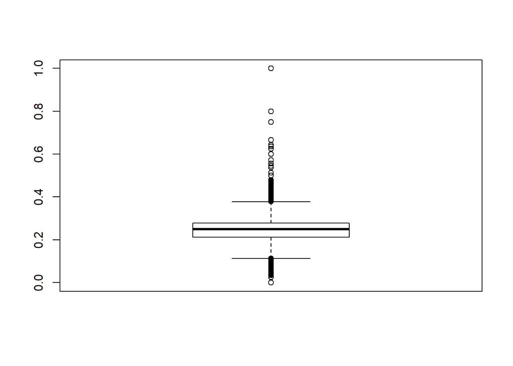

```r
boxplot(AppearBatSub_Clean$BA)
```

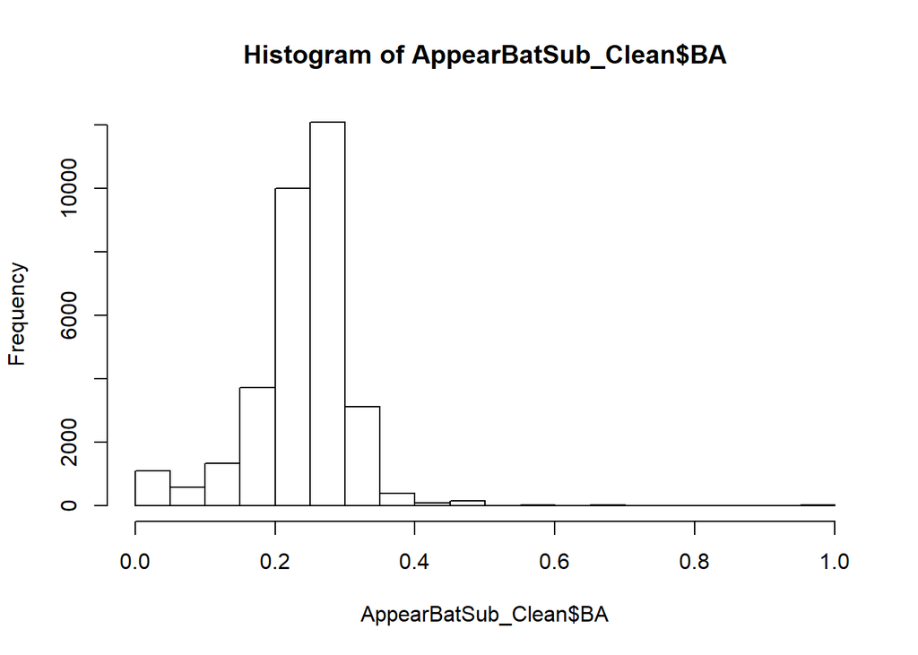

```r
hist(AppearBatSub_Clean$BA)
```

```r
summary(AppearBatSub_Clean$BA)
```

```
##    Min. 1st Qu.  Median    Mean 3rd Qu.    Max.
##  0.0000  0.2123  0.2500  0.2392  0.2785  1.0000
```

Possible outliers exist as seen by max value at 1, which is not the norm considering that most players average around .239. Outliers in BA could represent players with few at-bats, i.e. not regular players. Let’s look at the distribution of AB:

```r
summary(AppearBatSub_Clean$AB)
```

```
##    Min. 1st Qu.  Median    Mean 3rd Qu.    Max.
##     1.0    55.0   185.0   237.3   406.0   716.0
```

Distribution of AB shows the range is quite large from 1 AB to 716 in a single season. This brings into question whether we want to focus on players who have had a minimum number of At-Bats (AB) before modelling. Apart from starters, many other players make appearances throughout the season, so it would be difficult to define a minimum number of At-Bats to work with, so we decided not to invoke this condition since it would eliminate many players from our dataset.

Instead we use percentile capping on the BA outliers rather than remove them or impute to zero, because these outliers are likely natural outliers (not errors). Some players had very few At-Bats in a season so getting a couple of hits from a few At-Bats would result in a high average that’s not representative of good performance.

```r
qnt1 <- quantile(AppearBatSub_Clean$BA, probs=c(.25, .75),na.rm=T)
caps1 <- quantile(AppearBatSub_Clean$BA, probs=c(.05, .95),na.rm=T)
H1 <- 1.5*IQR(AppearBatSub_Clean$BA, na.rm=T)
AppearBatSub_Clean$BA[AppearBatSub_Clean$BA<(qnt1[1]-H1)] <- caps1[1]
AppearBatSub_Clean$BA[AppearBatSub_Clean$BA>(qnt1[2]+H1)] <- caps1[2]
```

Check max and min after outliers capped

```r
summary(AppearBatSub_Clean$BA)
```

```
##    Min. 1st Qu.  Median    Mean 3rd Qu.    Max.
##  0.1000  0.2123  0.2500  0.2402  0.2785  0.3778
```

Plots after outlier capping now reflect a more normal distribution

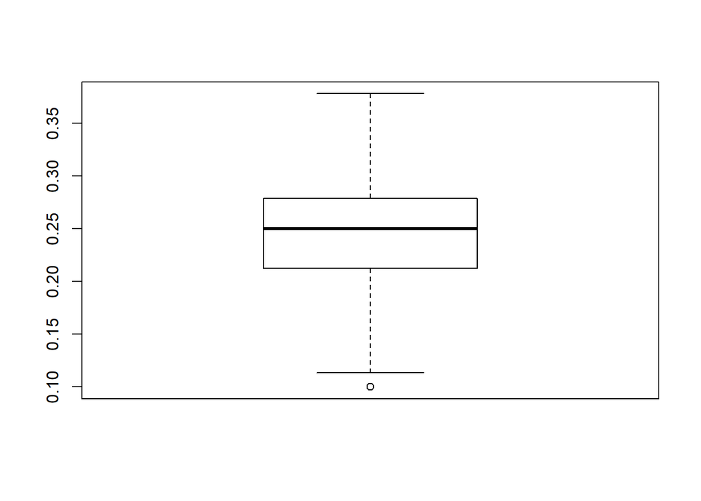

```r
boxplot(AppearBatSub_Clean$BA)
```

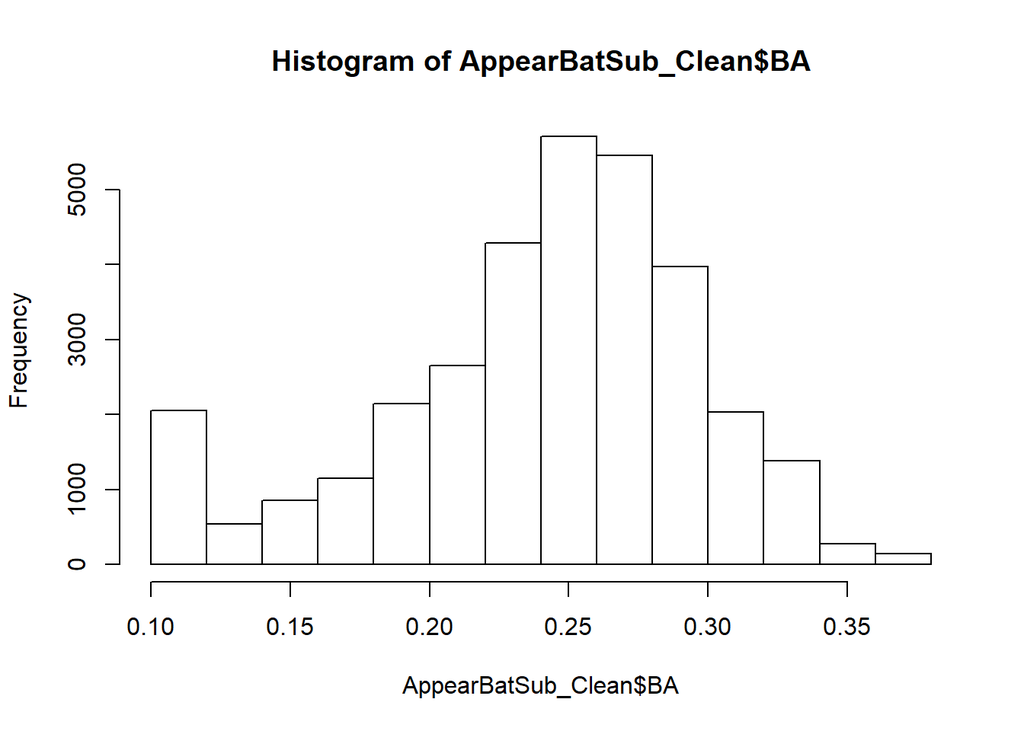

```r
hist(AppearBatSub_Clean$BA)
```

Let’s explore OPS

```r
summary(AppearBatSub_Clean$OPS)
```

```
##    Min. 1st Qu.  Median    Mean 3rd Qu.    Max.
##  0.0000  0.5776  0.6837  0.6629  0.7760  5.0000
```

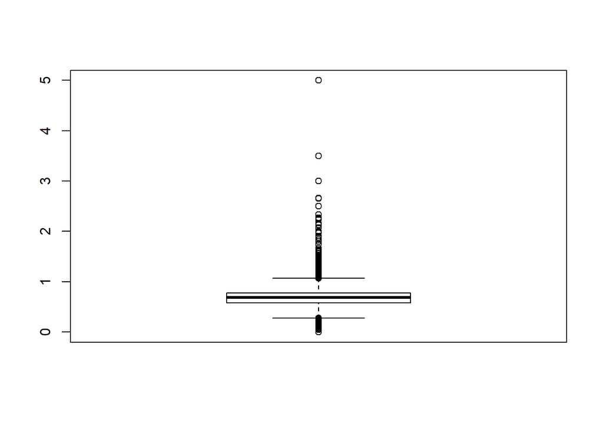

```r
boxplot(AppearBatSub_Clean$OPS)
```

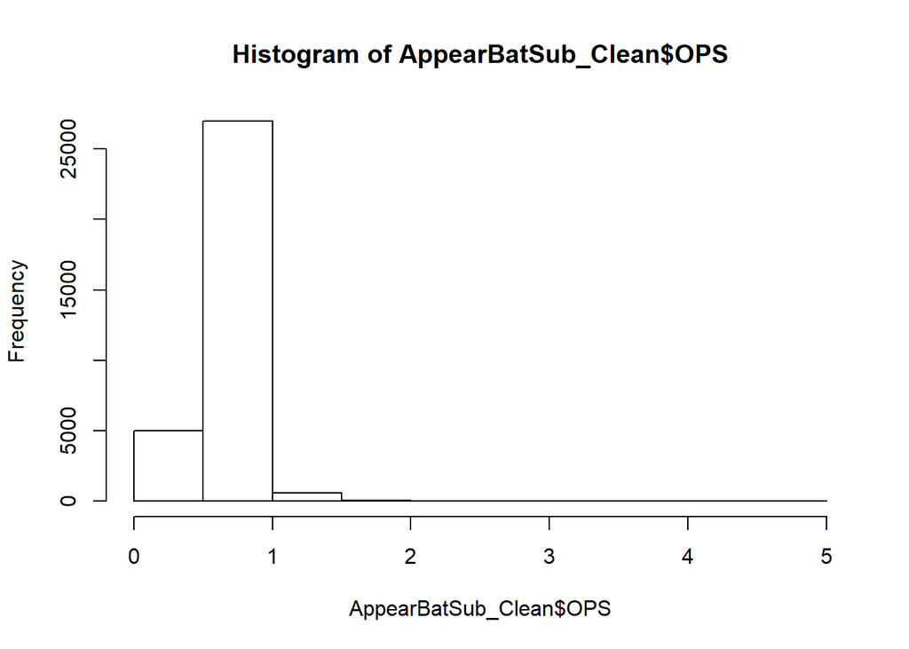

```r
hist(AppearBatSub_Clean$OPS)
```

Histogram of OPS shows that a greater number of OPS values are between 0.5 and 1. We will percentile cap the OPS outliers as well (like above treatment on BA outliers), since we don’t want to remove the values from the dataset, but we need to change the values because the outliers will skew the data and will reduce the model’s effectiveness (ex. OPS of 5 looks extreme given the best OPS in one season was 1.42177 (www.baseballreference.com)).

```r
qnt2 <- quantile(AppearBatSub_Clean$OPS, probs=c(.25, .75),na.rm=T)
caps2 <- quantile(AppearBatSub_Clean$OPS, probs=c(.05, .95),na.rm=T)
H2 <- 1.5*IQR(AppearBatSub_Clean$OPS, na.rm=T)
AppearBatSub_Clean$OPS[AppearBatSub_Clean$OPS<(qnt2[1]-H2)] <- caps2[1]
AppearBatSub_Clean$OPS[AppearBatSub_Clean$OPS>(qnt2[2]+H2)] <- caps2[2]

summary(AppearBatSub_Clean$OPS)
```

```
##    Min. 1st Qu.  Median    Mean 3rd Qu.    Max.
##  0.2815  0.5776  0.6837  0.6657  0.7760  1.0732
```

Let’s now explore the numeric variables a bit more through a multi-plot function:

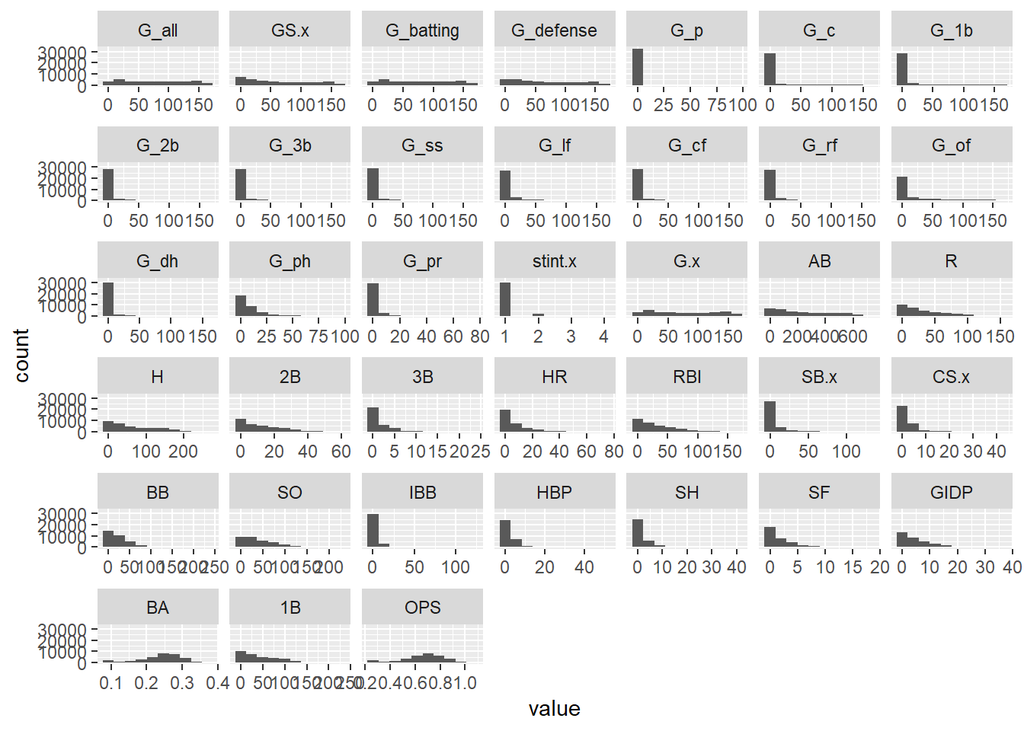

```r
# Get only numeric colums
list_of_numcols1 = sapply(AppearBatSub_Clean, is.numeric)
numcols1 = AppearBatSub_Clean[ , list_of_numcols1]
#Melt data --> Turn it into skinny LONG table - good to aggregate

library(reshape2)

melt_data1 = melt(numcols1, id.vars=c("yearID"))
#This data structure is now suitable for a multiplot function
ggplot(data = melt_data1, mapping = aes(x = value)) + geom_histogram(bins = 10) + facet_wrap(~variable, scales = 'free_x')
```

The above histograms indicate that it is rare for players to have high values for most of the attributes as the values are skewed towards zero, consistent with previous findings.

Add binary variable for target class OPS

```r
AppearBatSub_Clean$OPSClass=ifelse(AppearBatSub_Clean$OPS>=.8,"good","ok")
head(AppearBatSub_Clean$OPS)
```

```
## [1] 0.9185113 1.0000000 0.8539823 0.7804525 0.7093565 0.6666667
```

```r
head(AppearBatSub_Clean$OPSClass)
```

```
## [1] "good" "good" "good" "ok"   "ok"   "ok"
```

Identify improved players. We focus on the most recent 5 years.

First, create smaller dataframes with just the 2 years of interest by filtering based on yearID.

```r
mlbdata <- AppearBatSub_Clean
recent=c(2015,2016)
recent_b = c(2014, 2015)
recent_c = c(2013, 2014)
recent_d = c(2012, 2013)
recent_e = c(2011, 2012)

mlbdata1=filter(mlbdata,yearID %in% recent)
mlbdata_b=filter(mlbdata,yearID %in% recent_b)

mlbdata_c=filter(mlbdata,yearID %in% recent_c)

mlbdata_d=filter(mlbdata,yearID %in% recent_d)

mlbdata_e=filter(mlbdata,yearID %in% recent_e)
```

Next, separate the 2 years of interest into their own tables.

```r
#filter out 2015 & 2016 into their own tables
firstyr = filter(mlbdata1, yearID == 2015)
secyr=filter(mlbdata1, yearID == 2016)

#filter out 2014 & 2015 into their own tables
firstyr_b = filter(mlbdata_b, yearID == 2014)
secyr_b=filter(mlbdata_b, yearID == 2015)

#filter out 2013 & 2014 into their own tables
firstyr_c = filter(mlbdata_c, yearID == 2013)
secyr_c=filter(mlbdata_c, yearID == 2014)

#filter out 2012 & 2013 into their own tables
firstyr_d = filter(mlbdata_d, yearID == 2012)
secyr_d=filter(mlbdata_d, yearID == 2013)

#filter out 2011 & 2012 into their own tables
firstyr_e = filter(mlbdata_e, yearID == 2011)
secyr_e=filter(mlbdata_e, yearID == 2012)
```

Then, join the tables so that we have each of the 2 years’ data in separate columns. Left join was used because we wanted stats of players in the most recent year (ex. 2016) who existed in the previous year (ex.2015). If that condition was not met, then they did not form part of the resultant table called “new” (NAs resulted).

```r
#join 2015 and 2016 based on players in 2015
new=left_join(firstyr,secyr,by=c("playerID","teamID"),na=c("","NA","#NA"))
head(new)
```

```
##   yearID.x  playerID teamID lgID.x.x G_all.x GS.x.x G_batting.x
## 1     2015 abreujo02    CHA       AL     154    154         154
## 2     2015 ackledu01    NYA       AL      23     14          23
## 3     2015 ackledu01    SEA       AL      85     53          85
## 4     2015 adamecr01    COL       NL      26     13          26
## 5     2015 adamsma01    SLN       NL      60     42          60
## 6     2015 adriaeh01    SFN       NL      52     31          52
##   G_defense.x G_p.x G_c.x G_1b.x G_2b.x G_3b.x G_ss.x G_lf.x G_cf.x G_rf.x
## 1         115     0     0    115      0      0      0      0      0      0
## 2          17     0     0      4      9      0      0      4      0      0
## 3          79     0     0      0      1      0      0     63     21      2
## 4          15     0     0      0      2      0     13      0      0      0
## 5          46     0     0     46      0      0      0      0      0      0
## 6          42     0     0      1     20      1     20      0      0      0
##   G_of.x G_dh.x G_ph.x G_pr.x stint.x.x G.x.x AB.x R.x H.x 2B.x 3B.x HR.x
```

[output cut: 48 more lines]

```r
#join 2014 and 2015 based on players in 2014
new_b=left_join(firstyr_b,secyr_b,by=c("playerID","teamID"),na=c("","NA","#NA"))
head(new_b)
```

```
##   yearID.x  playerID teamID lgID.x.x G_all.x GS.x.x G_batting.x
## 1     2014 abreubo01    NYN       NL      78     29          78
## 2     2014 abreujo02    CHA       AL     145    144         145
## 3     2014 abreuto01    SFN       NL       3      0           3
## 4     2014 ackledu01    SEA       AL     143    131         143
## 5     2014 adamecr01    COL       NL       7      2           7
## 6     2014 adamsla01    KCA       AL       6      0           6
##   G_defense.x G_p.x G_c.x G_1b.x G_2b.x G_3b.x G_ss.x G_lf.x G_cf.x G_rf.x
## 1          31     0     0      0      0      0      0      5      0     26
## 2         109     0     0    109      0      0      0      0      0      0
## 3           2     0     0      0      1      1      0      0      0      0
## 4         133     0     0      0      0      0      0    133      0      0
## 5           7     0     0      0      2      0      5      0      0      0
## 6           2     0     0      0      0      0      0      2      2      0
##   G_of.x G_dh.x G_ph.x G_pr.x stint.x.x G.x.x AB.x R.x H.x 2B.x 3B.x HR.x
```

[output cut: 48 more lines]

```r
#join 2013 and 2014 based on players in 2013
new_c=left_join(firstyr_c,secyr_c,by=c("playerID","teamID"),na=c("","NA","#NA"))
head(new_c)
```

```
##   yearID.x  playerID teamID lgID.x.x G_all.x GS.x.x G_batting.x
## 1     2013 abreuto01    SFN       NL      53     25          53
## 2     2013 ackledu01    SEA       AL     113    103         113
## 3     2013 adamsda02    NYA       AL      43     38          43
## 4     2013 adamsma01    SLN       NL     108     63         108
## 5     2013 adducji02    TEX       AL      17      8          17
## 6     2013 adriaeh01    SFN       NL       9      4           9
##   G_defense.x G_p.x G_c.x G_1b.x G_2b.x G_3b.x G_ss.x G_lf.x G_cf.x G_rf.x
## 1          36     0     0      0     30      3      3      0      0      0
## 2         111     0     0      6     53      0      0     11     50      0
## 3          42     0     0      4      9     31      0      0      0      0
## 4          74     0     0     74      0      0      0      0      0      0
## 5          10     0     0      4      0      0      0      8      0      0
## 6           6     0     0      0      0      0      6      0      0      0
##   G_of.x G_dh.x G_ph.x G_pr.x stint.x.x G.x.x AB.x R.x H.x 2B.x 3B.x HR.x
```

[output cut: 48 more lines]

```r
#join 2012 and 2013 based on players in 2012
new_d=left_join(firstyr_d,secyr_d,by=c("playerID","teamID"),na=c("","NA","#NA"))
head(new_d)
```

```
##   yearID.x  playerID teamID lgID.x.x G_all.x GS.x.x G_batting.x
## 1     2012 abreubo01    LAA       AL       8      7           8
## 2     2012 abreubo01    LAN       NL      92     47          92
## 3     2012 abreuto01    KCA       AL      22     18          22
## 4     2012 ackledu01    SEA       AL     153    151         153
## 5     2012 adamsma01    SLN       NL      27     23          27
## 6     2012 allenbr01    OAK       AL       3      2           3
##   G_defense.x G_p.x G_c.x G_1b.x G_2b.x G_3b.x G_ss.x G_lf.x G_cf.x G_rf.x
## 1           7     0     0      0      0      0      0      6      0      1
## 2          47     0     0      0      0      0      0     46      0      1
## 3          19     0     0      0     11      6      4      0      0      0
## 4         147     0     0     11    142      0      0      0      0      0
## 5          24     0     0     24      0      0      0      0      0      0
## 6           3     0     0      3      0      0      0      0      0      0
##   G_of.x G_dh.x G_ph.x G_pr.x stint.x.x G.x.x AB.x R.x H.x 2B.x 3B.x HR.x
```

[output cut: 48 more lines]

```r
#join 2011 and 2012 based on players in 2011
new_e=left_join(firstyr_e,secyr_e,by=c("playerID","teamID"),na=c("","NA","#NA"))
head(new_e)
```

```
##   yearID.x  playerID teamID lgID.x.x G_all.x GS.x.x G_batting.x
## 1     2011 abreubo01    LAA       AL     142    135         142
## 2     2011 ackledu01    SEA       AL      90     87          90
## 3     2011 adamsry01    BAL       AL      29     24          29
## 4     2011 alfonel01    COL       NL      25     18          25
## 5     2011 allenbr01    ARI       NL      11      9          11
## 6     2011 allenbr01    OAK       AL      41     40          41
##   G_defense.x G_p.x G_c.x G_1b.x G_2b.x G_3b.x G_ss.x G_lf.x G_cf.x G_rf.x
## 1          28     0     0      0      0      0      0     18      0     10
## 2          86     0     0      1     86      0      0      0      0      0
## 3          26     0     0      0     26      0      0      0      0      0
## 4          19     0    19      0      0      0      0      0      0      0
## 5          10     0     0     10      0      0      0      0      0      0
## 6          41     0     0     41      0      0      0      0      0      0
##   G_of.x G_dh.x G_ph.x G_pr.x stint.x.x G.x.x AB.x R.x H.x 2B.x 3B.x HR.x
```

[output cut: 48 more lines]

Remove rows where there are NAs as these instances represent data that is not available in the later year to compare to the previous year

```r
new1=new[!is.na(new$yearID.y),]
summary(new1$yearID.y)
```

```
##    Min. 1st Qu.  Median    Mean 3rd Qu.    Max.
##    2016    2016    2016    2016    2016    2016
```

```r
new1_b=new_b[!is.na(new_b$yearID.y),]
summary(new1_b$yearID.y) #checked no more NAs
```

```
##    Min. 1st Qu.  Median    Mean 3rd Qu.    Max.
##    2015    2015    2015    2015    2015    2015
```

```r
new1_c=new_c[!is.na(new_c$yearID.y),]
summary(new1_c$yearID.y) #checked no more NAs
```

```
##    Min. 1st Qu.  Median    Mean 3rd Qu.    Max.
##    2014    2014    2014    2014    2014    2014
```

```r
new1_d=new_d[!is.na(new_d$yearID.y),]
summary(new1_d$yearID.y) #checked no more NAs
```

```
##    Min. 1st Qu.  Median    Mean 3rd Qu.    Max.
##    2013    2013    2013    2013    2013    2013
```

```r
new1_e=new_e[!is.na(new_e$yearID.y),]
summary(new1_e$yearID.y) #checked no more NAs
```

```
##    Min. 1st Qu.  Median    Mean 3rd Qu.    Max.
##    2012    2012    2012    2012    2012    2012
```

Add new class - whether or not improved from earlier year to the later year. Identified a new target class representing improvement from first year to second. If OPS is ok (i.e. <.800) in first year and increased to good (>=.800) in second year then the player has improved (Improved=Yes) otherwise no improvement is evident (Improved=No). Players who were already good (>= 0.800) in first year were removed from the dataset to focus on improved players.

```r
#add new class - whether or not improved from 2015 to 2016
new1 = filter(new1, OPS.x<0.800)
new1$Improved=ifelse(new1$OPSClass.x=="ok"&new1$OPSClass.y=="good","Yes","No")
head(new1$Improved)
```

```
## [1] "No" "No" "No" "No" "No" "No"
```

```r
#add new class - whether or not improved from 2014 to 2015
new1_b = filter(new1_b, OPS.x<0.800)
new1_b$Improved=ifelse(new1_b$OPSClass.x=="ok"&new1_b$OPSClass.y=="good","Yes","No")
head(new1_b$Improved)
```

```
## [1] "No" "No" "No" "No" "No" "No"
```

```r
#add new class - whether or not improved from 2013 to 2014
new1_c = filter(new1_c, OPS.x<0.800)
new1_c$Improved=ifelse(new1_c$OPSClass.x=="ok"&new1_c$OPSClass.y=="good","Yes","No")
head(new1_c$Improved)
```

```
## [1] "No" "No" "No" "No" "No" "No"
```

```r
#add new class - whether or not improved from 2012 to 2013
new1_d = filter(new1_d, OPS.x<0.800)
new1_d$Improved=ifelse(new1_d$OPSClass.x=="ok"&new1_d$OPSClass.y=="good","Yes","No")
head(new1_d$Improved)
```

```
## [1] "No"  "Yes" "No"  "No"  "No"  "No"
```

```r
#add new class - whether or not improved from 2011 to 2012
new1_e = filter(new1_e, OPS.x<0.800)
new1_e$Improved=ifelse(new1_e$OPSClass.x=="ok"&new1_e$OPSClass.y=="good","Yes","No")
head(new1_e$Improved)
```

```
## [1] "No" "No" "No" "No" "No" "No"
```

Combine all data into one called ‘total’

```r
total = rbind(new1, new1_b, new1_c, new1_d, new1_e)
nrow(total)
```

```
## [1] 1391
```

```r
summary(total)
```

```
##     yearID.x      playerID            teamID            lgID.x.x
##  Min.   :2011   Length:1391        Length:1391        Length:1391
##  1st Qu.:2012   Class :character   Class :character   Class :character
##  Median :2013   Mode  :character   Mode  :character   Mode  :character
##  Mean   :2013
##  3rd Qu.:2014
##  Max.   :2015
##     G_all.x           GS.x.x        G_batting.x      G_defense.x
##  Min.   :  1.00   Min.   :  0.00   Min.   :  1.00   Min.   :  1.0
##  1st Qu.: 43.00   1st Qu.: 29.00   1st Qu.: 43.00   1st Qu.: 34.0
##  Median : 89.00   Median : 68.00   Median : 89.00   Median : 76.0
##  Mean   : 86.06   Mean   : 72.86   Mean   : 86.06   Mean   : 77.5
##  3rd Qu.:131.00   3rd Qu.:118.00   3rd Qu.:131.00   3rd Qu.:122.0
##  Max.   :162.00   Max.   :162.00   Max.   :162.00   Max.   :162.0
##      G_p.x              G_c.x            G_1b.x            G_2b.x
##  Min.   : 0.00000   Min.   :  0.00   Min.   :  0.000   Min.   :  0.00
##  1st Qu.: 0.00000   1st Qu.:  0.00   1st Qu.:  0.000   1st Qu.:  0.00
##  Median : 0.00000   Median :  0.00   Median :  0.000   Median :  0.00
##  Mean   : 0.03523   Mean   : 10.74   Mean   :  7.167   Mean   : 11.63
##  3rd Qu.: 0.00000   3rd Qu.:  0.00   3rd Qu.:  0.000   3rd Qu.:  1.00
##  Max.   :21.00000   Max.   :146.00   Max.   :159.000   Max.   :160.00
##      G_3b.x            G_ss.x           G_lf.x            G_cf.x
##  Min.   :  0.000   Min.   :  0.00   Min.   :  0.000   Min.   :  0.00
##  1st Qu.:  0.000   1st Qu.:  0.00   1st Qu.:  0.000   1st Qu.:  0.00
##  Median :  0.000   Median :  0.00   Median :  0.000   Median :  0.00
##  Mean   :  9.699   Mean   : 12.41   Mean   :  9.285   Mean   : 10.78
##  3rd Qu.:  0.500   3rd Qu.:  0.00   3rd Qu.:  3.500   3rd Qu.:  0.00
##  Max.   :160.000   Max.   :162.00   Max.   :156.000   Max.   :157.00
##      G_rf.x            G_of.x           G_dh.x            G_ph.x
##  Min.   :  0.000   Min.   :  0.00   Min.   :  0.000   Min.   : 0.000
##  1st Qu.:  0.000   1st Qu.:  0.00   1st Qu.:  0.000   1st Qu.: 1.000
##  Median :  0.000   Median :  0.00   Median :  0.000   Median : 4.000
##  Mean   :  8.035   Mean   : 27.02   Mean   :  3.269   Mean   : 7.474
##  3rd Qu.:  2.000   3rd Qu.: 37.00   3rd Qu.:  2.000   3rd Qu.:10.000
##  Max.   :161.000   Max.   :161.00   Max.   :150.000   Max.   :71.000
##      G_pr.x         stint.x.x        G.x.x             AB.x
##  Min.   : 0.000   Min.   :1.00   Min.   :  1.00   Min.   :  1.0
##  1st Qu.: 0.000   1st Qu.:1.00   1st Qu.: 43.00   1st Qu.:112.0
##  Median : 0.000   Median :1.00   Median : 89.00   Median :263.0
##  Mean   : 1.354   Mean   :1.06   Mean   : 86.06   Mean   :282.9
```

[output cut: 99 more lines]

```
##  Max.   :24.00   Max.   :17.00   Max.   :12.000   Max.   :28.000
##       BA.y             1B.y           OPS.y         OPSClass.y
##  Min.   :0.1000   Min.   :  0.0   Min.   :0.2889   Length:1391
##  1st Qu.:0.2131   1st Qu.: 16.0   1st Qu.:0.5949   Class :character
##  Median :0.2462   Median : 44.0   Median :0.6843   Mode  :character
##  Mean   :0.2373   Mean   : 49.4   Mean   :0.6621
##  3rd Qu.:0.2704   3rd Qu.: 77.0   3rd Qu.:0.7544
##  Max.   :0.3750   Max.   :169.0   Max.   :1.0483
##    Improved
##  Length:1391
##  Class :character
##  Mode  :character
##
##
##
```

```r
head(total)
```

```
##   yearID.x  playerID teamID lgID.x.x G_all.x GS.x.x G_batting.x
## 1     2015 adamecr01    COL       NL      26     13          26
## 2     2015 adamsma01    SLN       NL      60     42          60
## 3     2015 adriaeh01    SFN       NL      52     31          52
## 4     2015 aguilje01    CLE       AL       7      5           7
## 5     2015 ahmedni01    ARI       NL     134    116         134
## 6     2015 alberha01    TEX       AL      41     26          41
##   G_defense.x G_p.x G_c.x G_1b.x G_2b.x G_3b.x G_ss.x G_lf.x G_cf.x G_rf.x
## 1          15     0     0      0      2      0     13      0      0      0
## 2          46     0     0     46      0      0      0      0      0      0
## 3          42     0     0      1     20      1     20      0      0      0
## 4           4     0     0      4      0      0      0      0      0      0
## 5         129     0     0      0      0      0    129      0      0      0
## 6          36     0     0      0     24      7      8      0      0      0
##   G_of.x G_dh.x G_ph.x G_pr.x stint.x.x G.x.x AB.x R.x H.x 2B.x 3B.x HR.x
```

[output cut: 48 more lines]

```r
# no. and proportion of improved players 2011 to 2016
freq_imp_tot=table(total$Improved)
head(freq_imp_tot)
```

```
##
##   No  Yes
## 1200  191
```

```r
prop.table(freq_imp_tot)
```

```
##
##        No       Yes
## 0.8626887 0.1373113
```

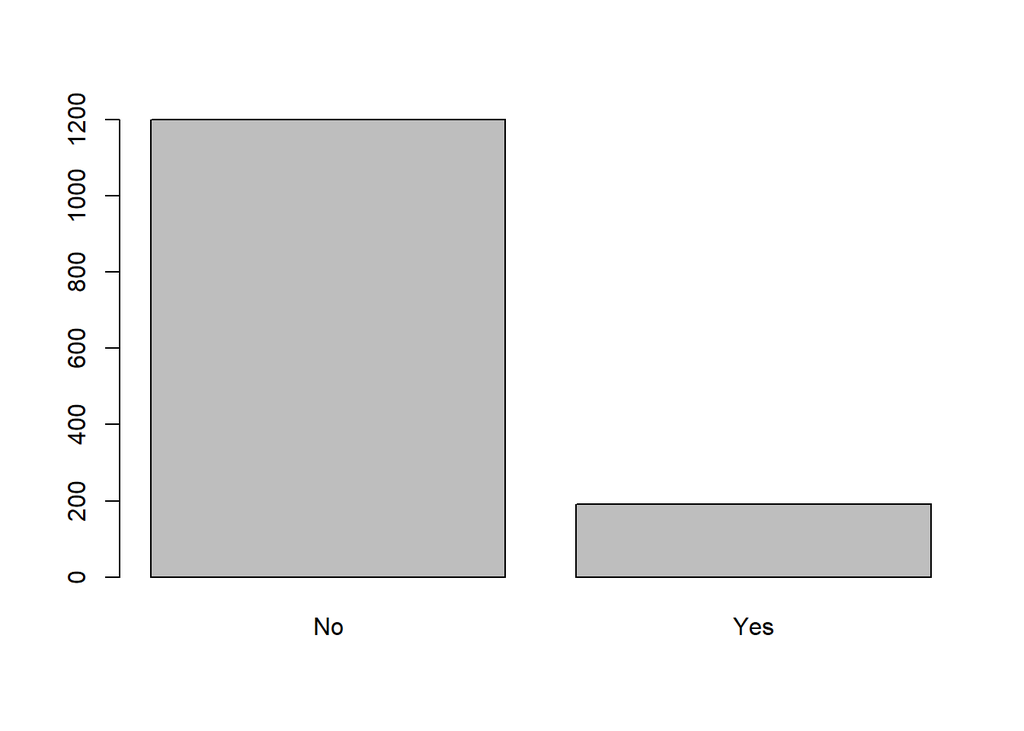

```r
barplot(freq_imp_tot)
```

Frequency of improved players compared to not improved shows most who were ok in the first year remained just ok in the second year. When looking at year over year comparisons from 2011 to 2016, 1,200 of ok players (86%) did not improve in the next year, while 191 did (14%).This finding supports the notion that it is difficult to move from being an “ok”" player to “good” from one year to the next.

Decision Tree Modelling based on Improved Class

First generate train and test sets

```r
#split data into train and test 70-30% split
require(caTools)
set.seed(101)
sampleimp = sample.split(total$Improved, SplitRatio = .70)
trainimp = subset(total, sampleimp == TRUE)
testimp = subset(total, sampleimp == FALSE)
```

Fit the decision tree model

```r
library(rpart)
(fitimp <- rpart(Improved ~R.x+RBI.x+BA.x+H.x+HR.x+IBB.x+SF.x+BB.x+AB.x+`2B.x`+`3B.x`+SB.x.x+CS.x.x+SO.x+HBP.x+SH.x+SO.x+GIDP.x,data=trainimp,method="class"))
```

```
## n= 974
##
## node), split, n, loss, yval, (yprob)
##       * denotes terminal node
##
##  1) root 974 134 No (0.8624230 0.1375770)
##    2) HR.x< 18.5 902 108 No (0.8802661 0.1197339)
##      4) GIDP.x< 14.5 830  88 No (0.8939759 0.1060241) *
##      5) GIDP.x>=14.5 72  20 No (0.7222222 0.2777778)
##       10) SO.x>=76 51   9 No (0.8235294 0.1764706) *
##       11) SO.x< 76 21  10 Yes (0.4761905 0.5238095)
##         22) SB.x.x>=2.5 11   2 No (0.8181818 0.1818182) *
##         23) SB.x.x< 2.5 10   1 Yes (0.1000000 0.9000000) *
##    3) HR.x>=18.5 72  26 No (0.6388889 0.3611111)
##      6) AB.x>=436 64  20 No (0.6875000 0.3125000)
##       12) IBB.x< 3.5 39   8 No (0.7948718 0.2051282) *
##       13) IBB.x>=3.5 25  12 No (0.5200000 0.4800000)
##         26) 2B.x< 30.5 16   5 No (0.6875000 0.3125000) *
##         27) 2B.x>=30.5 9   2 Yes (0.2222222 0.7777778) *
##      7) AB.x< 436 8   2 Yes (0.2500000 0.7500000) *
```

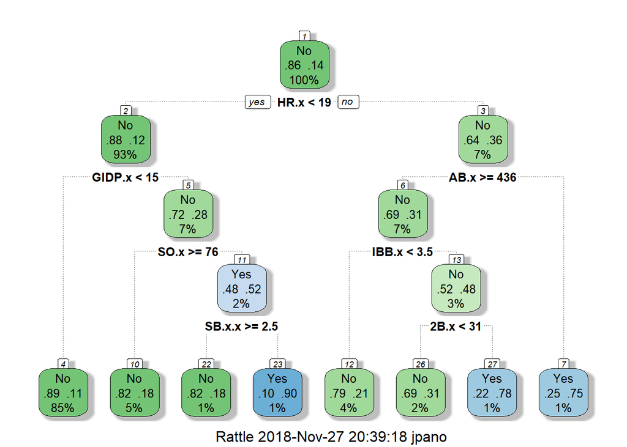

```r
library(rpart.plot)
library(rattle)
fancyRpartPlot(fitimp)
```

Determine confusion matrix and accuracy score on train set and then appyl model to test set and obtain accuracy

```r
#on training data
tree_predict=predict(fitimp,trainimp, type="class")
(conf_matrix=table(tree_predict,trainimp$Improved))
```

```
##
## tree_predict  No Yes
##          No  835 112
##          Yes   5  22
```

```r
accuracy<-(conf_matrix[1,1]+conf_matrix[2,2])/(sum(conf_matrix))
print(paste('Accuracy',accuracy))
```

```
## [1] "Accuracy 0.879876796714579"
```

```r
#validate on test data
validpred=predict(fitimp,testimp,type="class")
conf_matrix_val<-table(validpred,testimp$Improved)
conf_matrix_val
```

```
##
## validpred  No Yes
##       No  350  56
##       Yes  10   1
```

```r
accuracy_val<-(conf_matrix_val[1,1]+conf_matrix_val[2,2])/(sum(conf_matrix_val))
print(paste('Accuracy',accuracy_val))
```

```
## [1] "Accuracy 0.841726618705036"
```

Accuracy went down from 88% on training data to 84% on test data. On test data, the model predicted correctly 350 out of 360 instances for class NO, whereas only 1 out of 57 cases of class YES was predicted correctly. This is due to the training dataset being highly imbalanced. Although overall accuracy seems high (~85%), the prediction accuracy for class YES, which is the class of interest, needs improvement. The class NO is overrepresented in the training set. The algorithm that learns from this imbalanced training set would likely not perform well on examples in class YES as it did not receive enough information about the minority class YES when being trained.

To improve the fitted model, undersampling of majority class NO and oversampling of minority class YES will be used by applying the ROSE function on the training data. ROSE package provides functions to deal with binary classification problems when there are imbalanced classes like we have here where instances in class YES (improved players from one year to the next based on OPS) is rare.

Select attributes from the larger dataframe that could be potential predictors for the model

```r
trainimp = trainimp[c("R.x", "RBI.x", "H.x", "HR.x","IBB.x", "SF.x","BB.x", "AB.x","BA.x","SB.x.x","CS.x.x","SO.x","HBP.x","SH.x","GIDP.x","Improved")]
testimp = testimp[c("R.x", "RBI.x", "H.x", "HR.x","IBB.x", "SF.x","BB.x", "AB.x","BA.x","SB.x.x","CS.x.x","SO.x","HBP.x","SH.x","GIDP.x","Improved")]
```

Apply ROSE package

```r
library(ROSE)
data_balanced_rose <- ROSE(Improved ~ .,data = trainimp,seed = 1)$data
table(data_balanced_rose$Improved)
```

```
##
##  No Yes
## 504 470
```

```r
prop.table(table(data_balanced_rose$Improved))
```

```
##
##        No       Yes
## 0.5174538 0.4825462
```

```r
nrow(data_balanced_rose)
```

```
## [1] 974
```

```r
ncol(data_balanced_rose)
```

```
## [1] 16
```

After applying ROSE, a more balanced training dataset is created, which contains 470 instances in YES and 504 in NO (total 974 samples which is 70% of the original dataset containing 1,391 instances).

Let’s fit the model using the balanced data

```r
library(rpart)
(fitimp_bal <- rpart(Improved ~R.x+RBI.x+BA.x+H.x+HR.x+IBB.x+SF.x+BB.x+AB.x+SB.x.x+CS.x.x+SO.x+HBP.x+SH.x+SO.x+GIDP.x,data=data_balanced_rose,method="class"))
```

```
## n= 974
##
## node), split, n, loss, yval, (yprob)
##       * denotes terminal node
##
##   1) root 974 470 No (0.51745380 0.48254620)
##     2) HR.x< 14.37649 764 320 No (0.58115183 0.41884817)
##       4) SH.x>=2.317263 210  52 No (0.75238095 0.24761905)
##         8) GIDP.x< 13.29073 176  31 No (0.82386364 0.17613636)
##          16) BB.x< 67.22285 169  25 No (0.85207101 0.14792899) *
##          17) BB.x>=67.22285 7   1 Yes (0.14285714 0.85714286) *
##         9) GIDP.x>=13.29073 34  13 Yes (0.38235294 0.61764706)
##          18) SH.x>=5.21917 11   1 No (0.90909091 0.09090909) *
##          19) SH.x< 5.21917 23   3 Yes (0.13043478 0.86956522) *
##       5) SH.x< 2.317263 554 268 No (0.51624549 0.48375451)
##        10) IBB.x< 3.19615 458 197 No (0.56986900 0.43013100)
##          20) AB.x< 402.6351 384 147 No (0.61718750 0.38281250)
##            40) BA.x>=0.1841808 289  91 No (0.68512111 0.31487889) *
##            41) BA.x< 0.1841808 95  39 Yes (0.41052632 0.58947368)
##              82) GIDP.x< 5.374152 74  36 Yes (0.48648649 0.51351351)
##               164) H.x>=-25.88153 60  25 No (0.58333333 0.41666667) *
##               165) H.x< -25.88153 14   1 Yes (0.07142857 0.92857143) *
##              83) GIDP.x>=5.374152 21   3 Yes (0.14285714 0.85714286) *
##          21) AB.x>=402.6351 74  24 Yes (0.32432432 0.67567568) *
##        11) IBB.x>=3.19615 96  25 Yes (0.26041667 0.73958333) *
##     3) HR.x>=14.37649 210  60 Yes (0.28571429 0.71428571) *
```

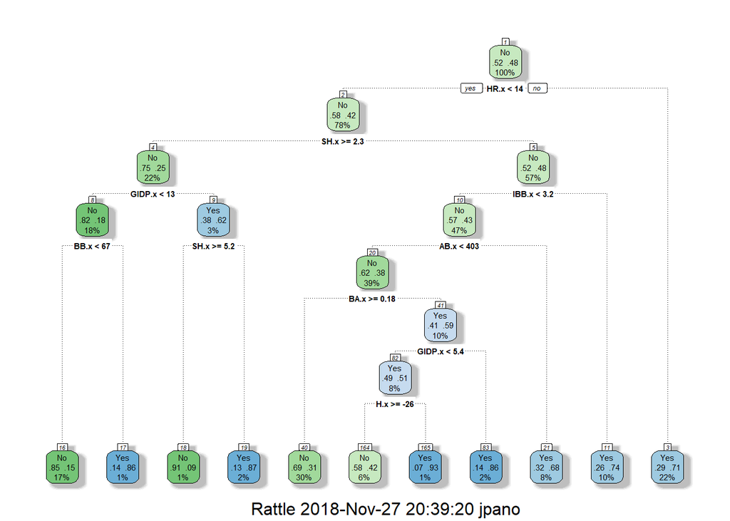

```r
library(rpart.plot)
library(rattle)
fancyRpartPlot(fitimp_bal)
```